# Central Limit Theorem

March 9, 2020

## M&M’s

Directions:

- Everyone pair off (one group of 3 is fine).
- Everyone will get three bags of M&M’s. For each bag:
  - Count the number of each color. Enter your results here: https://forms.gle/ev7vBVsN8UkcoftK8
- As a pair, calculate the mean, standard deviation, and standard error for the total number of M&M’s in each bag (i.e. n = 6).

\[\hat{\mu} = \frac{\#\ of\ M\&Ms}{\#\ of\ M\&M\ bags}\] \[{ s }^{ 2 }=\sum _{ i=1 }^{ n }{ \frac { { \left( { x }_{ i }-\bar { x } \right) }^{ 2 } }{ n-1 } }\] \[s=\sqrt{s^2}\] \[SE = \frac{s}{\sqrt{n}}\]

## Results

```r
results <- googlesheets4::read_sheet(results_url)
results[is.na(results$Red),]$Red <- 0
results[is.na(results$Green),]$Green <- 0
results[is.na(results$Orange),]$Orange <- 0
results[is.na(results$Blue),]$Blue <- 0
results$Total <- apply(results[,3:ncol(results)], 1, FUN = sum)
```

| Flavor | Blue | Brown | Green | Orange | Red | Yellow | Total |
| --- | --- | --- | --- | --- | --- | --- | --- |
| Milk Chocolate | 6 | 2 | 0 | 2 | 3 | 2 | 15 |
| Peanut | 0 | 0 | 2 | 2 | 1 | 2 | 7 |
| Caramel | 1 | 0 | 2 | 0 | 0 | 1 | 4 |
| Peanut Butter | 1 | 6 | 3 | 0 | 0 | 1 | 11 |
| Caramel | 2 | 1 | 0 | 1 | 0 | 2 | 6 |
| Milk Chocolate | 5 | 1 | 0 | 5 | 1 | 2 | 14 |
| Peanut | 2 | 1 | 1 | 0 | 0 | 3 | 7 |
| Caramel | 0 | 1 | 2 | 1 | 3 | 0 | 7 |
| Peanut | 0 | 0 | 3 | 3 | 0 | 0 | 6 |
| Caramel | 2 | 1 | 3 | 0 | 1 | 0 | 7 |

[output cut: 47 more lines]

## Distribution of number of M&M’s per bag

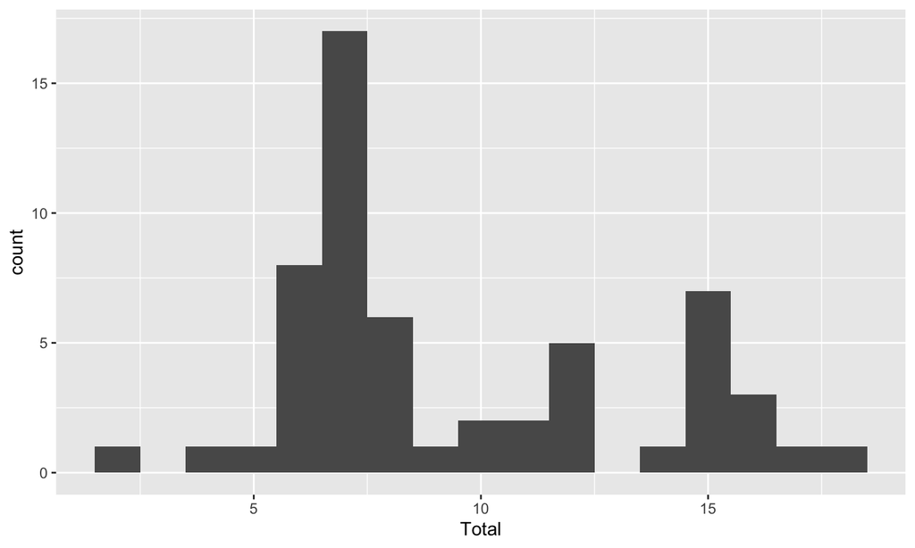

```r
ggplot(results, aes(x = Total)) + geom_histogram(binwidth = 1)
```

## Standard Error

```r
(se <- sd(results$Total) / sqrt(nrow(results)))
```

```
## [1] 0.5154688
```

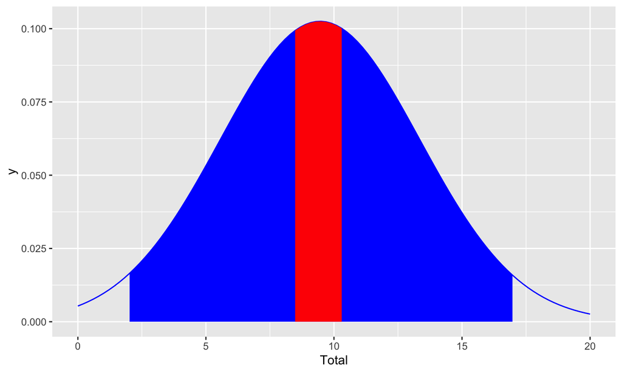

## Descriptive Statistics

```r
mean(results$Total)
```

```
## [1] 9.45614
```

```r
sd(results$Total)
```

```
## [1] 3.891704
```

```r
results.tab <- data.frame(Color = names(colors),
                          Count = unname(apply(results[,names(colors)], 2, sum)),
                          stringsAsFactors = FALSE)
results.tab$Observed <- results.tab$Count / sum(results.tab$Count)
results.tab
```

```
##    Color Count  Observed
## 1   Blue   109 0.2022263
## 2  Brown    64 0.1187384
## 3  Green   114 0.2115028
## 4 Orange    90 0.1669759
## 5    Red    67 0.1243043
## 6 Yellow    95 0.1762523
```

## Distribution of Colors

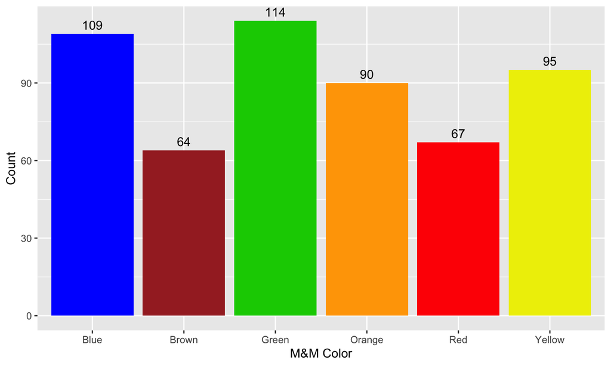

```r
ggplot(results.tab, aes(x = Color, y = Count, fill = Color, label = Count)) +
    geom_bar(stat = 'identity') + scale_fill_manual(NULL, values = colors) +
    geom_text(vjust = -0.5) + ylab('Count') + xlab('M&M Color') + theme(legend.position = 'none')
```

## Expected Outcomes

According to the manufacturer of M&M candy, the color distribution for plain chocolate M&Ms is 13% brown, 13% red, 14% yellow, 24% blue, 20% orange, and 16% green. Do the M&Ms in our sample suggest that the color distribution is different?

```r
expected <- data.frame(
    Color = c('Blue', 'Brown', 'Green', 'Orange', 'Red', 'Yellow'),
    Expected = c(.24, .13, .16, .20, .13, .14),
    Expected_Count = c(.24, .13, .16, .20, .13, .14) * sum(results.tab$Count),
    stringsAsFactors = FALSE
)
expected
```

```
##    Color Expected Expected_Count
## 1   Blue     0.24         129.36
## 2  Brown     0.13          70.07
## 3  Green     0.16          86.24
## 4 Orange     0.20         107.80
## 5    Red     0.13          70.07
## 6 Yellow     0.14          75.46
```

## Central limit theoreom for proportions

Sample proportions will be nearly normally distributed with mean equal to the population mean, *p*, and standard error equal to \(\sqrt{\frac{p(1-p)}{n}}\).

\[\hat { p } \sim N\left( mean=p,SE=\sqrt { \frac { p(1-p) }{ n } } \right) \]

This is true given the following conditions:

- independent observations
- at least 10 successes and 10 failures

## How many red M&M’s should we expect?

```r
red_m_and_m <- results$Red / results$Total
head(red_m_and_m)
```

```
## [1] 0.20000000 0.14285714 0.00000000 0.00000000 0.00000000 0.07142857
```

```r
(p <- mean(red_m_and_m))
```

```
## [1] 0.1117598
```

```r
(se <- sqrt(p * (1 - p) / length(red_m_and_m) ))
```

```
## [1] 0.04173214
```

```r
c(p - 1.96 * se, p + 1.96 * se)
```

```
## [1] 0.02996484 0.19355482
```

## Distribution of Red M&M’s

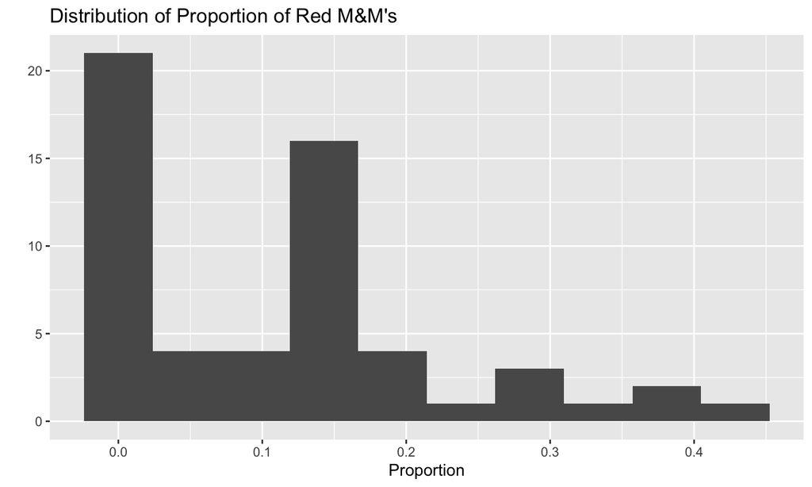

```r
qplot(red_m_and_m, bins = 10) + ggtitle("Distribution of Proportion of Red M&M's") + xlab('Proportion')
```

## Weldon’s dice

- Walter Frank Raphael Weldon (1860 - 1906), was an English evolutionary biologist and a founder of biometry. He was the joint founding editor of Biometrika, with Francis Galton and Karl Pearson.
- In 1894, he rolled 12 dice 26,306 times, and recorded the number of 5s or 6s (which he considered to be a success).
  - It was observed that 5s or 6s occurred more often than expected, and Pearson hypothesized that this was probably due to the construction of the dice. Most inexpensive dice have hollowed-out pips, and since opposite sides add to 7, the face with 6 pips is lighter than its opposing face, which has only 1 pip.

## Labby’s dice

In 2009, Zacariah Labby (U of Chicago), repeated Weldon’s experiment using a homemade dice-throwing, pip counting machine. http:// www.youtube.com/ watch?v= 95EErdouO2w

- The rolling-imaging process took about 20 seconds per roll.
  - Each day there were ∼150 images to process manually.
  - At this rate Weldon’s experiment was repeated in a little more than six full days.
  - Recommended reading: http://galton.uchicago.edu/about/docs/labby09dice.pdf

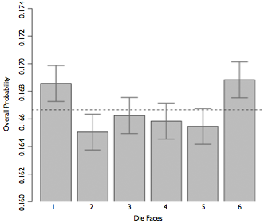

## Summarizing Labby’s results

The table below shows the observed and expected counts from Labby’s experiment.

| Outcome | Observed | Expected |
| --- | --- | --- |
| 1 | 53,222 | 52,612 |
| 2 | 52,118 | 52,612 |
| 3 | 52,465 | 52,612 |
| 4 | 52,338 | 52,612 |
| 5 | 52,244 | 52,612 |
| 6 | 53,285 | 52,612 |
| Total | 315,672 | 315,672 |

## Setting the hypotheses

Do these data provide convincing evidence of an inconsistency between the observed and expected counts?

- `$H_0$`: There is no inconsistency between the observed and the expected counts. The observed counts follow the same distribution as the expected counts.
- `$H_A$`: There is an inconsistency between the observed and the expected counts. The observed counts **do not** follow the same distribution as the expected counts. There is a bias in which side comes up on the roll of a die.

## Evaluating the hypotheses

- To evaluate these hypotheses, we quantify how different the observed counts are from the expected counts.
- Large deviations from what would be expected based on sampling variation (chance) alone provide strong evidence for the alternative hypothesis.
- This is called a test since we’re evaluating how well the observed data fit the expected distribution.

## Anatomy of a test statistic

- The general form of a test statistic is:

\[\frac{\text{point estimate} - \text{null value}}{\text{SE of point estimate}}\]

- This construction is based on
  1. identifying the difference between a point estimate and an expected value if the null hypothesis was true, and
  2. standardizing that difference using the standard error of the point estimate.
- These two ideas will help in the construction of an appropriate test statistic for count data.

## Chi-Squared

When dealing with counts and investigating how far the observed counts are from the expected counts, we use a new test statistic called the chi-square (\(\chi^2\)) statistic.

\[\chi^2 = \sum_{i = 1}^k \frac{(O - E)^2}{E} \qquad \text{where $k$ = total number of cells}\]

| Outcome | Observed | Expected | \(\frac{(O - E)^2}{E}\) |
| --- | --- | --- | --- |
| 1 | 53,222 | 52,612 | \(\frac{(53,222 - 52,612)^2}{52,612} = 7.07\) |
| 2 | 52,118 | 52,612 | \(\frac{(52,118 - 52,612)^2}{52,612} = 4.64\) |
| 3 | 52,465 | 52,612 | \(\frac{(52,465 - 52,612)^2}{52,612} = 0.41\) |
| 4 | 52,338 | 52,612 | \(\frac{(52,338 - 52,612)^2}{52,612} = 1.43\) |
| 5 | 52,244 | 52,612 | \(\frac{(52,244 - 52,612)^2}{52,612} = 2.57\) |
| 6 | 53,285 | 52,612 | \(\frac{(53,285 - 52,612)^2}{52,612} = 8.61\) |
| Total | 315,672 | 315,672 | 24.73 |

## Chi-Squared Distribution

Squaring the difference between the observed and the expected outcome does two things:

- Any standardized difference that is squared will now be positive.
- Differences that already looked unusual will become much larger after being squared.

In order to determine if the \(\chi^2\) statistic we calculated is considered unusually high or not we need to first describe its distribution.

- The chi-square distribution has just one parameter called **degrees of freedom (df)**, which influences the shape, center, and spread of the distribution.

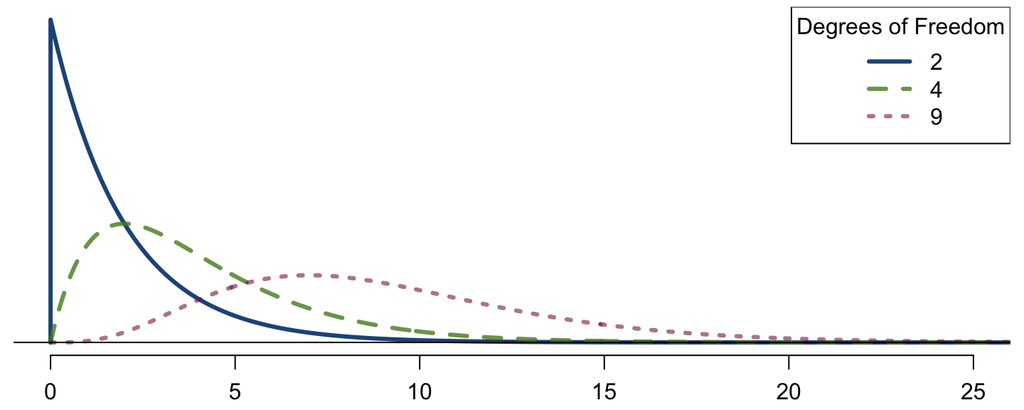

## Degrees of freedom for a goodness of fit test

When conducting a goodness of fit test to evaluate how well the observed data follow an expected distribution, the degrees of freedom are calculated as the number of cells (\(k\)) minus 1.

\[df = k - 1\]

For dice outcomes, \(k = 6\), therefore \(df = 6 - 1 = 5\)

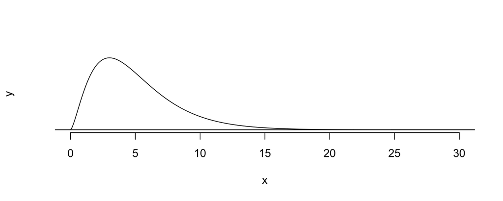

## Turns out…

- The 1-6 axis is consistently shorter than the other two (2-5 and 3-4), thereby supporting the hypothesis that the faces with one and six pips are larger than the other faces.
- Pearson’s claim that 5s and 6s appear more often due to the carved-out pips is not supported by these data.
- Dice used in casinos have flush faces, where the pips are filled in with a plastic of the same density as the surrounding material and are precisely balanced.

## Chi-Squared for M&M’s

```r
df <- 5 # 6 colors (or groups) minus 1
results.tab <- merge(results.tab, expected, by = 'Color')
(chi2 <- sum( (results.tab$Count - results.tab$Expected_Count)^2 / results.tab$Expected_Count ) )
```

```
## [1] 20.79947
```

## Observed vs. Expected Distributions

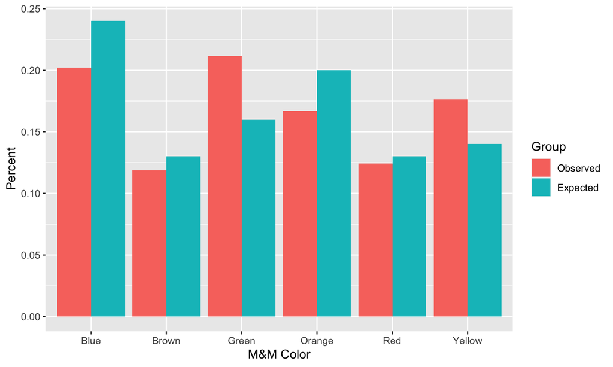

## Chi-Squared Distribution

```r
dchisq(chi2, df = df)
```

```
## [1] 0.0003839899
```

```r
qchisq(.95, df = df) # Chi-squared would need to reject the null hypothesis
```

```
## [1] 11.0705
```

## Recap: p-value for a chi-square test

- The p-value for a chi-square test is defined as the tail area **above** the calculated test statistic.

** This is because the test statistic is always positive, and a higher test statistic means a stronger deviation from the null hypothesis.

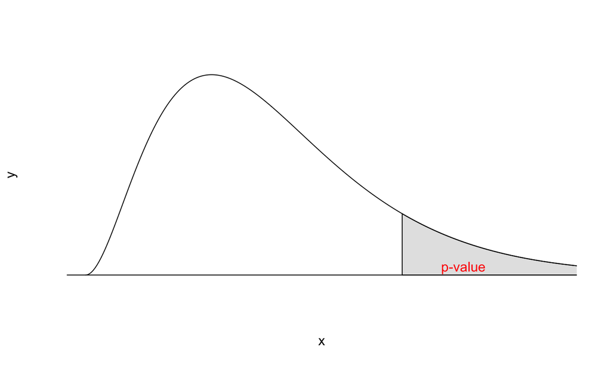